# EarthObservation Classification QGIS Plugin

### Clustering: theory, code implementation and comparison in Python

#### By Xu Qiongjie (10757496)

#### Supervised by Professor Giovanna Venuti

> github: https://github.com/ictar/EO-Classification-Plugin

# Clustering

Clustering is unsupervised process which divides the population or data points into a number of groups or clusters such that data points in same cluster are more similar to other points in the same clusters than points in other clusters.

## Distance / Dissimilarity

Data points are classified based on the distance between two element. The distance between two points can be defined as follows: $$ \mathbf{d(x, y) = [\sum_{i=1}^n|x_i - y_i|^q]^{1/q}} \\ \text{where }x \text{ and } y \text{ are two vectors of length }n. $$

- When q = 2, we have Euclidean distance
- When q = 1, we have Manhattan distance

## Clustering Methods

### Hierarchical Methods

This category performs a stepwise classification, and the adjective "hierarchical" means that the choices done at each step are never reconsidered. Starting from a dissimilarity (distance table) of each point with respect to all the other ones, we have two different kinds of method:

[output not shown]

### Optimization Methods

This class of clustering methods derives from the minimization of a target function: $$ \mathbf{\Phi_{\alpha,p}(\omega_{ic}, \underline{m}_c) = \sum_c\sum_i\omega_{ic}^\alpha|\underline{x}_i-\underline{m}_c|_{\ell^p}} \\ where \\ \alpha = \text{power for the weights. 1 implies a hard classification methods while 2 implies a soft classification} \\ \omega_{ic} = \text{weight / cluster membership} \\ \underline{m}_c = \text{cluster representative element} \\ \underline{x}_i = \text{element to be classified} \\ {\ell^p} = \text{kind of distance} $$

Different values of $\alpha$ and $p$ characterize different optimization methods:

| $\alpha$ | $p$ | Methods |
| --- | --- | --- |
| 1 | 1 | **PAM (partitioning around medoids)** |
| 1 | 2 | **K-means (partitioning around the mean)** |
| 2 | 2 | **FUZZY** |

## Cluster Validity

### Silhouette Index

Silhouette value is a measure of how similar an object is to its own cluster compared to other clusters. It ranges from -1 to 1, where a high value means the point is well mathed to its cluster and poorly matched to neighboring clusters.

Silhouette analysis could also help us to assess parameters like number of clusters visually.

$$ a(i)={\frac {1}{|C_{I}|-1}}\sum _{j\in C_{I},i\neq j}d(i,j) \quad i \in C_I\\ b(i)=\min _{J\neq I}{\frac {1}{|C_{J}|}}\sum _{j\in C_{J}}d(i,j) \quad i \in C_I\\ s(i)={\frac {b(i)-a(i)}{\max\{a(i),b(i)\}}}, \quad if \quad |C_{I}|>1 $$

### Confusion Matrix

Confusion Matrix is a specific matrix which allows visualization of the performance of an algorithm. Each row of the matrix represents the instances in an actual class while each column represents the instances in a predicted class, or vice versa.

|  |  | Predicted |  |
| --- | --- | --- | --- |
|  |  | **Positive** | **Negative** |
| **Observed** | **Positive** | True Positive (TP) | False Negative (FN) |
|  | **Negative** | False Positive (FP) | True Negative (TN) |

From a confusion matrix, we can derive the following index: $$ accuracy(ACC) = \frac{TP+TN}{TP+TN+FP+FN} $$

# QGIS and QGIS plugins

QGIS is a free and open-source Geographic Information System. The functionality of QGIS can be extended using plugins and plugins can be written in Python, which is easier to develop and simpler for distribution than C++ plugins. During the development, PyQt is used, which is a Python binding of the cross-platform GUI toolkit Qt.

# EO Clustering Plugins

In this plugin, we implement DIANA and FUZZY algorithms based on a previous Matlab implementation.

- These algorithms are implemented as a python package and invoked by the plugin.
- The implementation of the algorithms are tested against other implementation and show positive results.
- The clustering results are compared to understand their pros and cons.
- The plugin is also tested in the QGIS.

## Testing

### Accuracy

Both algorithms are run and compared with the results generated by the Matlab implementation on 1-dimension and 2-dimension dataset.

FUZZY is also compared with [SckiKit](https://scikit-fuzzy.readthedocs.io/en/latest/), which is a fuzzy logic toolbox for SciPy.

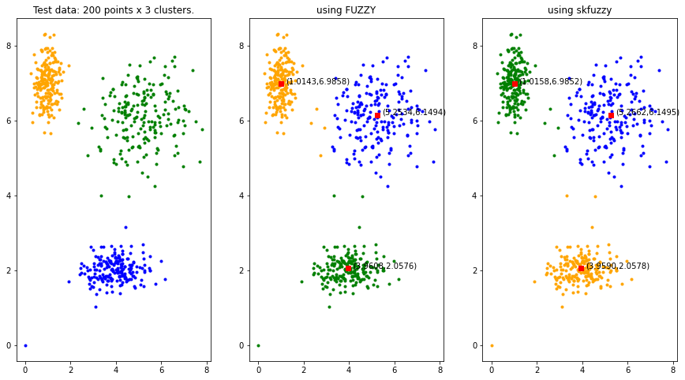

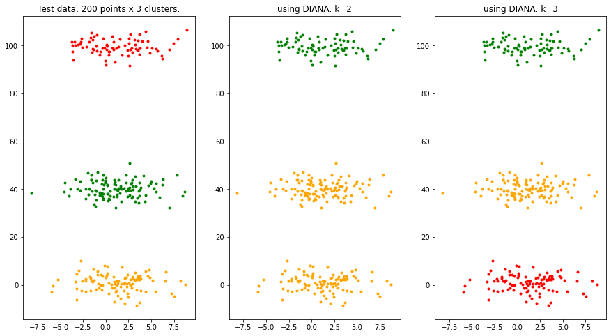

### Performance

The performance of the algorithms are tested on the datasets with different population. All datasets are generated by "SIMUDATA" function in Matlab script, with the same number of clusters (3), same number of bands (2), same means and covariance of clusters, and equal probability of clusters.

The result shows that the running time and number of misclassified points of DIANA increases sharply with the increase of the number of samples, while the running time and number of misclassified points of FUZZY is basically unchanged.

- The number of misclassified points are calculated by comparing the real labels generated by SIMUDATA and the labels from the algorithm.
- The elapsed time is execution time of a algorithm.

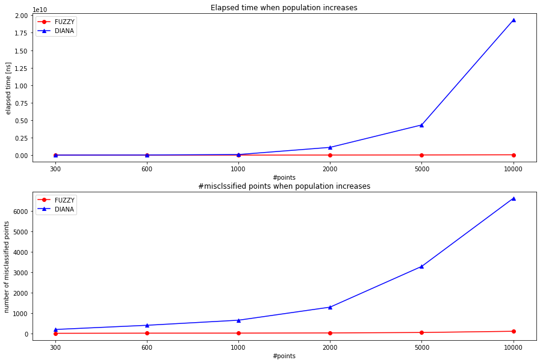

## Comparison between different variance and mean distance

This section shows how DIANA and FUZZY are affected by increased variance and the distance between the cluster means. 16 different datasets are generated by "SIMUDATA" function in Matlab script:

- the common variables for all datasets
  - number of the data to be generated (300)
  - number of clusters (3)
  - model probability of clusters (equal for each cluster)

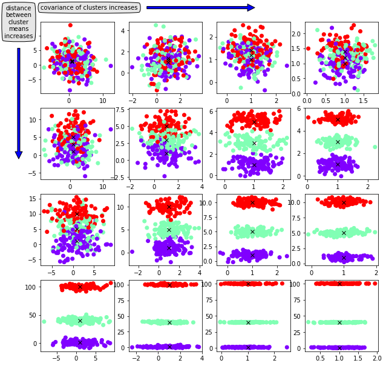

Firstly, we compare between different distance between cluster means with the same covariance.

According to the results shown below, we can see that in FUZZY, the number of misclassified points decreases as the distance between cluster means increase, while the running time is basically unchanged.

On the other hand, in DIANA, as the distance between cluster means increase, the number of misclassified points decreases as well, and the running time is almost unchanged.

Overall, the performance of FUZZY is slightly better than DIANA.

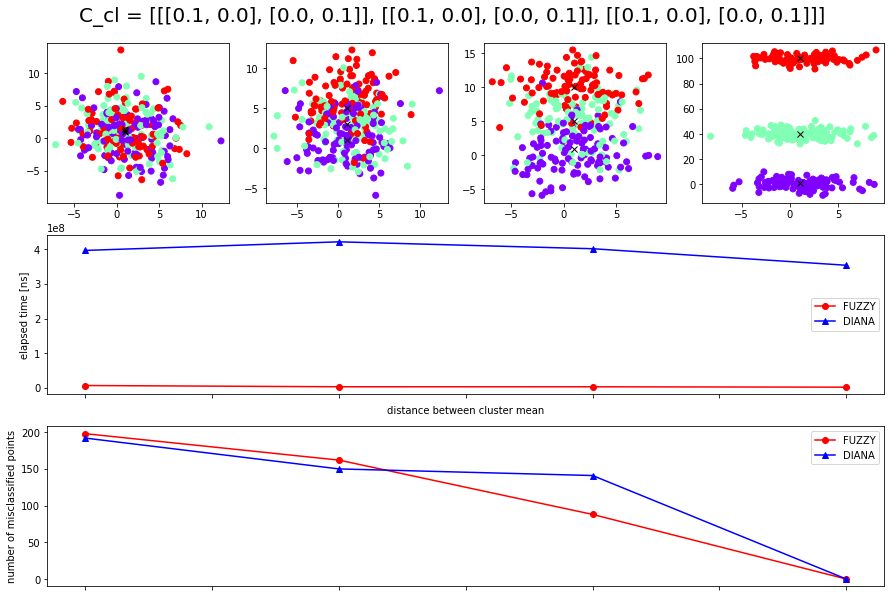

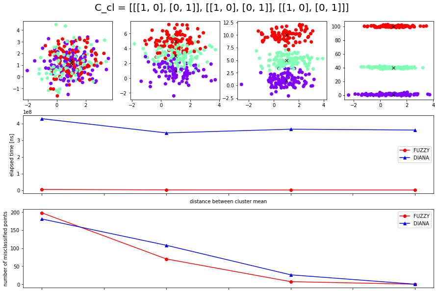

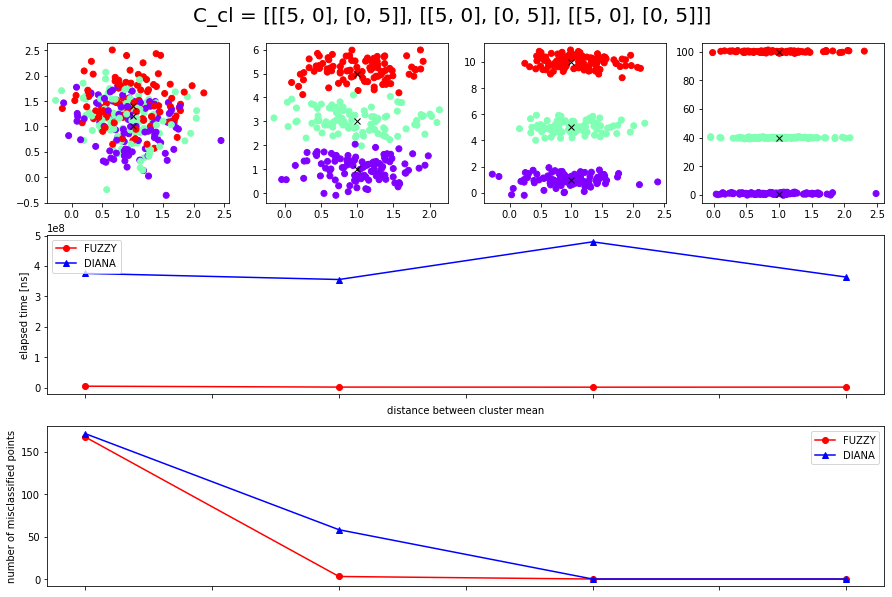

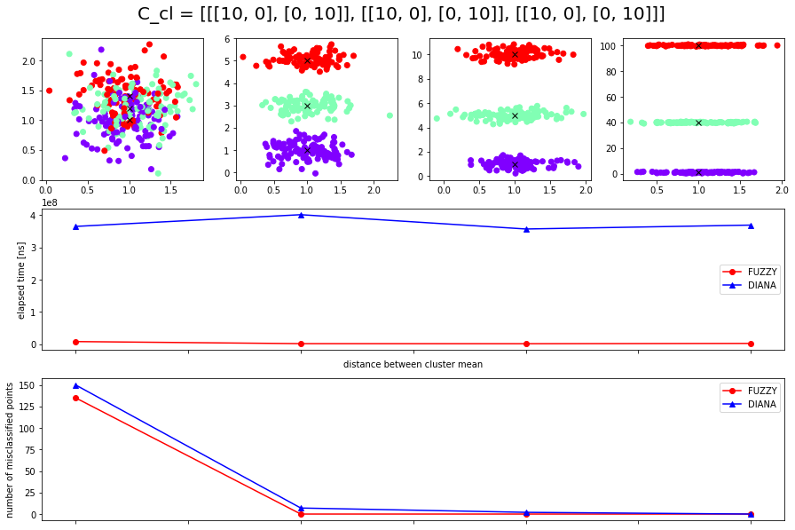

Then, compare between different variance with same distance between cluster mean.

According to the results shown below, we can see that in FUZZY, the number of misclassified points decreases as the variance increase, while the running time is basically unchanged.

On the other hand, in DIANA, as the variance increase, the number of misclassified points decreases as well, and the running time is almost unchanged.

Overall, the performance of FUZZY is slightly better than DIANA.

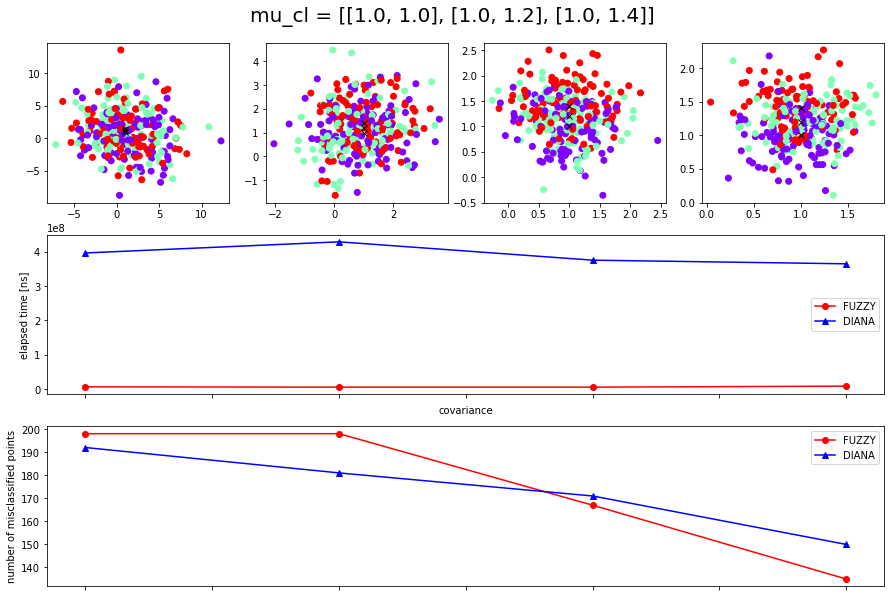

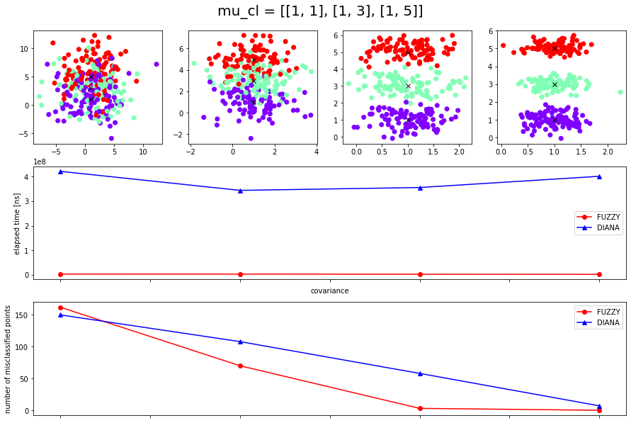

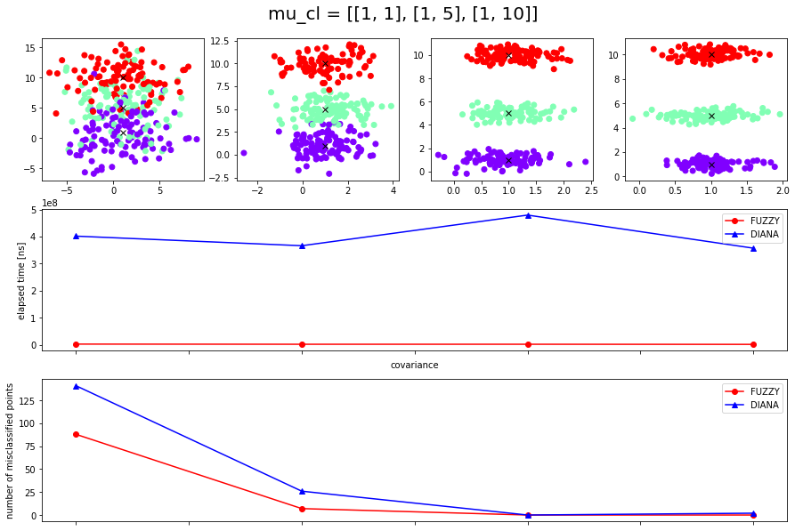

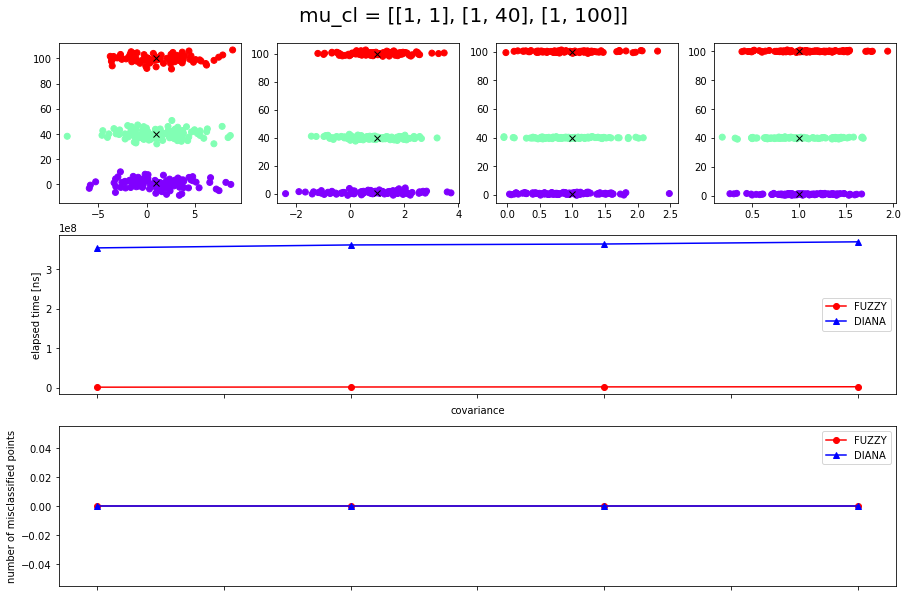

## Run in QGIS

After the classification algorithms are tested, we now can integrate them into the QGIS plugin. In the plugin:

[output not shown]

### Accuracy

Firstly, test the algorithms using the data with 1 band. The raster file we adopt contains only two values: 0 and 1. Besides, we would compare the result of the two algorithms with the other QGIS plugin implementation. Here, we choose [KMeansClassification in Orfeo ToolBox](https://www.orfeo-toolbox.org/CookBook/Applications/app_KMeansClassification.html).

The result shows that in such simple case, all algorithms classsify correctly.

| **Description** | Original Raster | Result of FUZZY | Result of DIANA | Result of KMeans |
| --- | --- | --- | --- | --- |
| **Result** |  |  |  |  |
| **Silhouette Index (from plugin log)** | -- | 1 | 1 | -- |
| Confusion Matrix (compared with origin using `sklearn.metrics.confusion_matrix`) | -- | $$\begin{bmatrix}1048 & 0\\0 & 633\end{bmatrix}$$ | $$\begin{bmatrix}1048 & 0\\0 & 633\end{bmatrix}$$ | $$\begin{bmatrix}1048 & 0\\0 & 633\end{bmatrix}$$ |
| Accuracy (compared with origin using `sklearn.metrics.accuracy_score`) | -- | 1.0 | 1.0 | 1.0 |

Then, we test the algorithms using the data with NIR band. Again, we would compare the result of the two algorithms with the result generated by [KMeansClassification in Orfeo ToolBox](https://www.orfeo-toolbox.org/CookBook/Applications/app_KMeansClassification.html) and compute the confusion matrix using the KMeans result as the true label.

| **Description** | Original Raster | Result of FUZZY | Result of DIANA | Result of KMeans |
| --- | --- | --- | --- | --- |
| **Result** |  |  |  |  |
| **Silhouette Index (from plugin log)** | -- | 0.6931 | 0.6928 | -- |
| Confusion Matrix (compared with KMeans Result using `sklearn.metrics.confusion_matrix`) | -- | $$\begin{bmatrix}942 & 0 \\3 & 736 \end{bmatrix}$$ | $$\begin{bmatrix}942 & 0 \\0 & 739 &\end{bmatrix}$$ | -- |
| Accuracy (compared with origin using `sklearn.metrics.accuracy_score`) | -- | 0.9982 | 1.0 | -- |

It shows that the result generated by DIANA is same with the result generated by KMeans, and the result generated by FUZZY is almost the same with the result generated by KMeans.

Next, we add red band on the basis of the previous test.

| **Description** | Original Raster | Result of FUZZY | Result of DIANA | Result of KMeans |
| --- | --- | --- | --- | --- |
| **Result** |  |  |  |  |
| **Silhouette Index (from plugin log)** | -- | 0.6177 | 0.6171 | -- |
| Confusion Matrix (compared with KMeans Result using `sklearn.metrics.confusion_matrix`) | -- | $$\begin{bmatrix}910 & 36 \\34 & 701 \end{bmatrix}$$ | $$\begin{bmatrix}906 & 40 \\31 & 704 &\end{bmatrix}$$ | -- |
| Accuracy (compared with origin using `sklearn.metrics.accuracy_score`) | -- | 0.9584 | 0.9578 | -- |

The results show that adding a new band is not better than the original result.

# Summary

- The Matlab implementation for DIANA store the labels for every iteration, which is memory consuming when applied to large dataset. Therefore, in python implementation, only the previous and the current labels are stored.
- DIANA method is easy to understand and implement. But the disavantages are obvisous. It rarely provides the best solution. This may be because DIANA alwasy divides the data and never merge the similar ones. Besides, the computational cost is very high, which make it not pratical for Earth Observation since the raster file always contain large data such that the runtime is unacceptable.
- Whether dealing with big data or noisy data, FUZZY algorithm shows better performance than DIANA algorithm.

# Reference

- Lectures of Earth Observation in Politecnico
- [PyQGIS Developer Cookbook](https://docs.qgis.org/3.22/en/docs/pyqgis_developer_cookbook/)
- WIKI: Silhouette_(clustering))
- [WIKI: Confusion Matrix](https://en.wikipedia.org/wiki/Confusion_matrix)
- Matlab implementation

# Code Organization

```
eo_classification/
├── Makefile
├── README.html
├── README.txt
├── Support
├── __init__.py
├── __pycache__
├── classification # classification algorithm
│   ├── __init__.py
│   ├── __pycache__
│   ├── distance.py
│   ├── hierarchical.py # hierarchical method, DIANA
│   ├── optimization.py # optimization method, FUZZY
│   ├── plots.py
│   └── statistics.py # methods for calculate si, #misclassified points
├── eo_classification.py # main logic of plugin
├── eo_classification_dialog.py
├── eo_classification_dialog_base.ui # used in Qt for UI
├── eo_classification_dialog_base.ui.autosave
├── help
├── i18n
├── icon.png
├── images
├── metadata.txt
├── pb_tool.cfg
├── plugin_upload.py
├── presentation.ipynb
├── pylintrc
├── resources.py
├── resources.qrc
├── scripts
├── test
└── test_classification
    ├── __init__.py
    ├── __pycache__
    ├── compare.json
    ├── compare.py
    ├── data
    │   ├── compare # folder, containing datasets for comparison
    │   ├── data_2_3_601.txt
    │   ├── performance # folder, containing datasets for performance
    │   ├── simudata.py
    │   ├── test_raster.tif
    │   ├── test_raster.tif.aux.xml
    │   ├── test_raster_1.tif
    │   └── test_raster_1.tif.aux.xml
    ├── performance.json
    ├── pylib.py
    ├── test_hierarchical.py
    └── test_optimization.py
```